# Tsarkova2HW

Царькова Анастасия

19 ноября 2016 г

## Введние

В данной работе произведен анализ корреляции различных признаков пациенток, проходивших с 2006 по 2008 вакцинацию против папилломавируса человека препаратом Гардасил, с использованием Крамер v для категориальных признаков и статистического критерия хи-квадрат, а так же различных методов визуализации данных. Для устранения проблемы проблемы проверки множественных гипотез использовался метод Холма.

## Построение и визуализация матрицы кореляций

Поскольку все признаки категориальные, будем использовать корреляцию Крамера V.

```r
DT <- read.xls("gardasil.xls")
DT$Completed = (DT$Shots == 3) & (DT$Completed.within.12.months == "yes")
features = c("Completed", "Race", "Clinic", "Practice.type", "AgeGroup", "Insurance.type", "Location.type")

corr_matrix = as.data.frame(matrix(0, ncol = length(features), nrow = length(features)))
colnames(corr_matrix) = features
rownames(corr_matrix) = features
for(row in features) {
    for(col in features) {
        distr_table = table(DT[,row], DT[,col])
        corr_matrix[row, col] = cramersV(distr_table)
    }
}
print(corr_matrix)
```

```
##                 Completed       Race    Clinic Practice.type   AgeGroup
## Completed      0.99840424 0.13853661 0.1488551    0.07730612 0.06460793
## Race           0.13853661 1.00000000 0.2081869    0.16339041 0.08365934
## Clinic         0.14885514 0.20818694 1.0000000    0.57403251 0.38401751
## Practice.type  0.07730612 0.16339041 0.5740325    1.00000000 0.65117152
## AgeGroup       0.06460793 0.08365934 0.3840175    0.65117152 0.99857376
## Insurance.type 0.14879279 0.18255004 0.4135536    0.35189922 0.29333099
## Location.type  0.11246459 0.25579387 1.0000000    0.48808285 0.20764431
##                Insurance.type Location.type
## Completed           0.1487928     0.1124646
## Race                0.1825500     0.2557939
## Clinic              0.4135536     1.0000000
## Practice.type       0.3518992     0.4880829
## AgeGroup            0.2933310     0.2076443
## Insurance.type      1.0000000     0.6337143
## Location.type       0.6337143     0.9983697
```

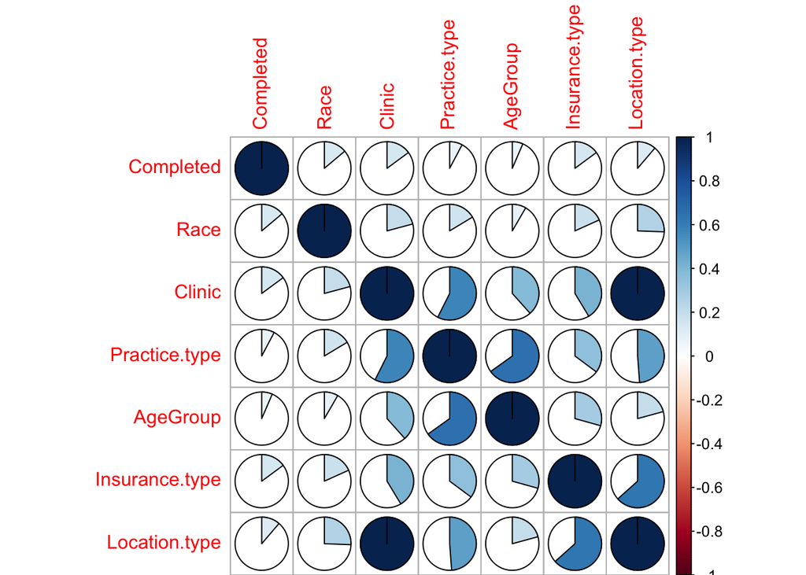

```r
corrplot(as.matrix(corr_matrix), method="pie")
```

```r
print(p.adjust(
    lapply(
        c("Race", "Clinic", "Practice.type", "AgeGroup", "Insurance.type", "Location.type"),
        function(feature) chisq.test(table(DT[,"Completed"], DT[,feature]))$p.value
    ),method="holm"
) < 0.01)
```

```
## [1]  TRUE  TRUE FALSE FALSE  TRUE  TRUE
```

Из результатов проверки статистической значимости значения корреляции видно, что такие признаки как “Practice.type” и “AgeGroup” можно назвать не коррелирующими с признаком Completed – завершенностью курса лечения. А “Race”, “Clinic”, “Insurance.type”, “Location.type” – коррелирующими

Ниже можем видеть, что процент завершенности лечения зависит от рассы: черные люди завершают лечение только в 20 процентов случаев, испанские и непонятные где-то на 35 процентов, белые на 40 процентов. Возможно, зависимость обосновывается каким-то другим фактором, например, тем, что люди разных национальностей живут на немного разной территории и посещают другие клиники, а клиника тоже связана с уровнем прохождения лечения.

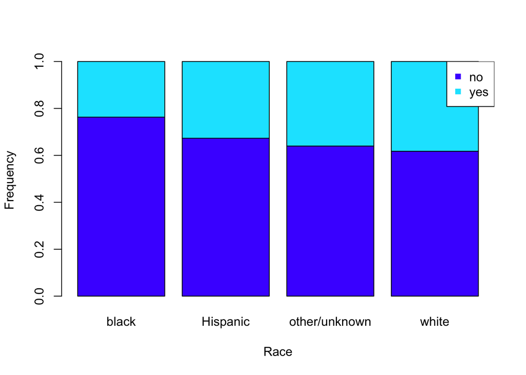

Ниже видим зависимость прохождения лечения от клиник. Связь кажется оправданной, потому что врачи в разных клиниках могут по-разному настаивать на завершении лечения, или же по-разному организовывать этот процесс.

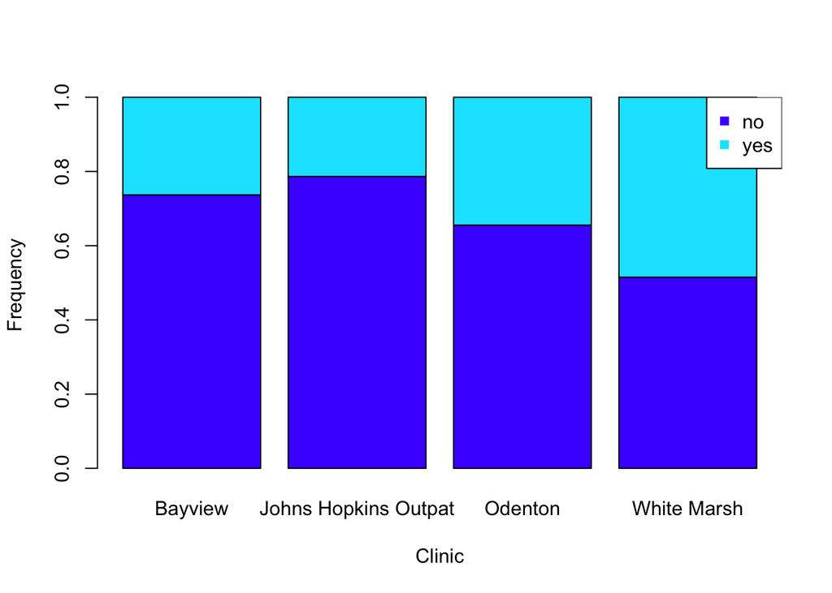

Видим, что в случае страховки medical assistance меньший процент людей завершает лечение.

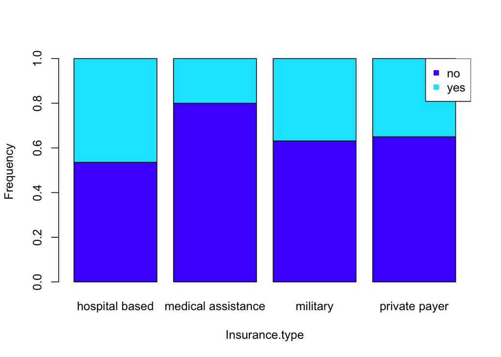

Видим, что люди из пригорода завершают лечение в большем числе случаев, чем люди из города. Скорей всего, эта связь тоже неявная через третий признак: клиники. Признак “клиники” и location type очень сильно связаны, как видно из диаграммы вначале работы.

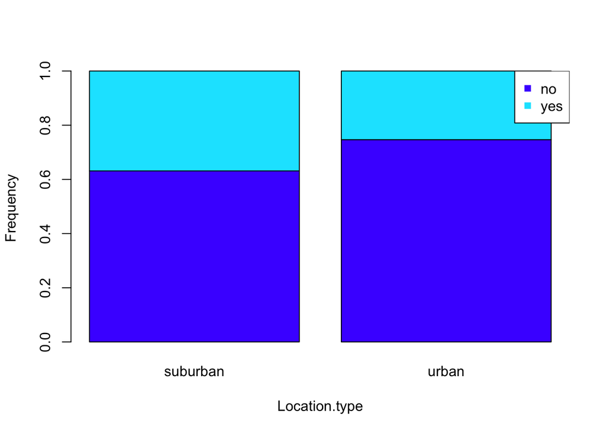